# Práctica 5 — Predicción Espacial: Kriging Ordinario, Kriging Universal y Validación Cruzada

- Mostrar todo el código
- Ocultar todo el código
- Ver el código fuente

Introducción a la Ciencia de Datos Espaciales

Autor/a

Afiliación

Francisco Javier Rodríguez Cortés

Departamento de Estadística - UNALMED

Fecha de publicación

29 de octubre de 2026

# 1 Introducción

En la Práctica 4 simulamos campos espaciales con una estructura de covarianza conocida —con media constante y con una tendencia de gran escala— y ajustamos modelos de semivariograma tanto a esos datos simulados como a los datos reales de temperatura de la Ciénaga Grande. Un modelo de semivariograma ajustado no es, por sí mismo, el objetivo final: es un insumo para **predecir** el valor de la variable en ubicaciones donde no se midió. Esa predicción espacial basada en la estructura de covarianza se llama **Kriging**.

Cubrimos dos variantes:

- **Kriging ordinario (KO)**: asume una media constante (pero desconocida) en toda la región de estudio.
- **Kriging universal (KU)**: permite que la media varíe como una función de las coordenadas (una tendencia), de modo que la predicción combina esa tendencia con la correlación espacial de los residuales.

Y cerramos con la pregunta que siempre debe acompañar a cualquier modelo de predicción: ¿qué tan bien predice realmente? Para eso usamos **validación cruzada leave-one-out**.

**Nota**

Esta práctica retoma los objetos (`datos_sf`, `v_1er_orden`, los modelos ajustados) de la Práctica 4, pero los reconstruye aquí desde cero para que el documento sea autocontenido y pueda ejecutarse de forma independiente.

## 1.1 Objetivos de aprendizaje

Al finalizar esta práctica, el estudiante estará en capacidad de:

1. Explicar la diferencia conceptual entre Kriging ordinario y Kriging universal, y predecir en qué circunstancias sus predicciones difieren de forma importante.
2. Construir una malla de predicción espacial, incluyendo el recorte de dicha malla a un polígono de interés usando `sf`.
3. Ejecutar Kriging ordinario y Kriging universal con `gstat::krige()` y mapear tanto la predicción como su incertidumbre (varianza/desviación estándar de Kriging).
4. Reconocer que la diferencia entre KO y KU es más marcada en **extrapolación** (fuera de la zona bien muestreada) que en interpolación dentro de ella.
5. Evaluar el desempeño predictivo de un modelo de Kriging mediante validación cruzada *leave-one-out*, e interpretar el RMSE, la correlación observado-predicho y los residuales estandarizados.
6. Distinguir **desempeño predictivo** de **interpretabilidad de los parámetros** del semivariograma, y explicar por qué un modelo puede predecir razonablemente bien incluso cuando sus parámetros (rango, meseta) no están bien identificados.

# 2 Preparación del entorno

**Mostrar/ocultar código**

```r
library(sf)
library(gstat)
library(tidyverse)
library(knitr)
library(scales)
```

**TipActualización de paquetes**

Si alguno de estos paquetes no está instalado, o está desactualizado:

**Mostrar/ocultar código**

```r
install.packages(c("sf", "gstat", "tidyverse", "knitr", "scales"))
```

# 3 Kriging sobre datos simulados

## 3.1 Repaso: los campos simulados y sus modelos de semivariograma

Reconstruimos, con la misma semilla que en la Práctica 4, los dos campos simulados sobre una malla de $10\times10$: uno con media constante (20) y otro con una tendencia lineal $10+2x+3y$, ambos con un modelo de covarianza exponencial subyacente (meseta 4, rango práctico 7). Para cada uno, ajustamos un modelo de semivariograma por mínimos cuadrados ponderados (el detalle de esa comparación de modelos está en la Práctica 4; aquí solo necesitamos el mejor ajuste para poder predecir).

**Mostrar/ocultar código**

```r
grid <- expand.grid(x = 0:9, y = 0:9)
modelo_exp_true <- vgm(psill = 4, model = "Exp", range = 7/3, nugget = 0)

set.seed(2026)
distancia  <- as.matrix(dist(grid))
covarianza <- 4 * exp(-3 * distancia / 7)
invisible(MASS::mvrnorm(1, rep(20, nrow(grid)), covarianza))  # mantiene el estado del RNG igual que en la Práctica 4

g_cte  <- gstat(formula = z ~ 1, locations = ~x + y, dummy = TRUE, beta = 20,
                model = modelo_exp_true, nmax = 100)
sim_cte <- predict(g_cte, newdata = grid, nsim = 1)$sim1
```

```
[using unconditional Gaussian simulation]
```

**Mostrar/ocultar código**

```r
invisible(MASS::mvrnorm(1, 10 + 2*grid$x + 3*grid$y, covarianza))
g_ncte <- gstat(formula = z ~ x + y, locations = ~x + y, dummy = TRUE, beta = c(10, 2, 3),
                model = modelo_exp_true, nmax = 100)
sim_ncte <- predict(g_ncte, newdata = grid, nsim = 1)$sim1
```

```
[using unconditional Gaussian simulation]
```

**Mostrar/ocultar código**

```r
sf_cte  <- st_as_sf(tibble(x = grid$x, y = grid$y, z = sim_cte),  coords = c("x", "y"), remove = FALSE)
sf_ncte <- st_as_sf(tibble(x = grid$x, y = grid$y, z = sim_ncte), coords = c("x", "y"), remove = FALSE)
```

**Mostrar/ocultar código**

```r
v_cte  <- variogram(z ~ 1,     sf_cte,  cutoff = 7, width = 1)
v_ncte <- variogram(z ~ x + y, sf_ncte, cutoff = 7, width = 1)

modelo_cte_fit  <- fit.variogram(v_cte,  vgm(psill = 4, model = "Sph", range = 5, nugget = 0.1))
modelo_ncte_fit <- fit.variogram(v_ncte, vgm(psill = 4, model = "Sph", range = 5, nugget = 0.1))
```

## 3.2 Una malla de predicción con zona de extrapolación

Para que la comparación entre Kriging ordinario y universal sea informativa, la malla de predicción no puede limitarse al mismo cuadrado $[0,9]\times[0,9]$ donde están los datos: dentro de esa región, *cualquier* interpolador razonable —con o sin tendencia explícita— tiende a seguir de cerca los valores observados cercanos. Las diferencias importantes entre KO y KU aparecen al **extrapolar**, fuera de la zona bien muestreada. Por eso extendemos la malla hasta $[-4,13]\times[-4,13]$:

**Mostrar/ocultar código**

```r
malla_sim <- expand.grid(x = seq(-4, 13, by = 0.5), y = seq(-4, 13, by = 0.5))
malla_sim$zona <- ifelse(malla_sim$x < 0 | malla_sim$x > 9 | malla_sim$y < 0 | malla_sim$y > 9,
                          "Extrapolación", "Interpolación")
malla_sim_sf <- st_as_sf(malla_sim, coords = c("x", "y"), remove = FALSE)
```

**Mostrar/ocultar código**

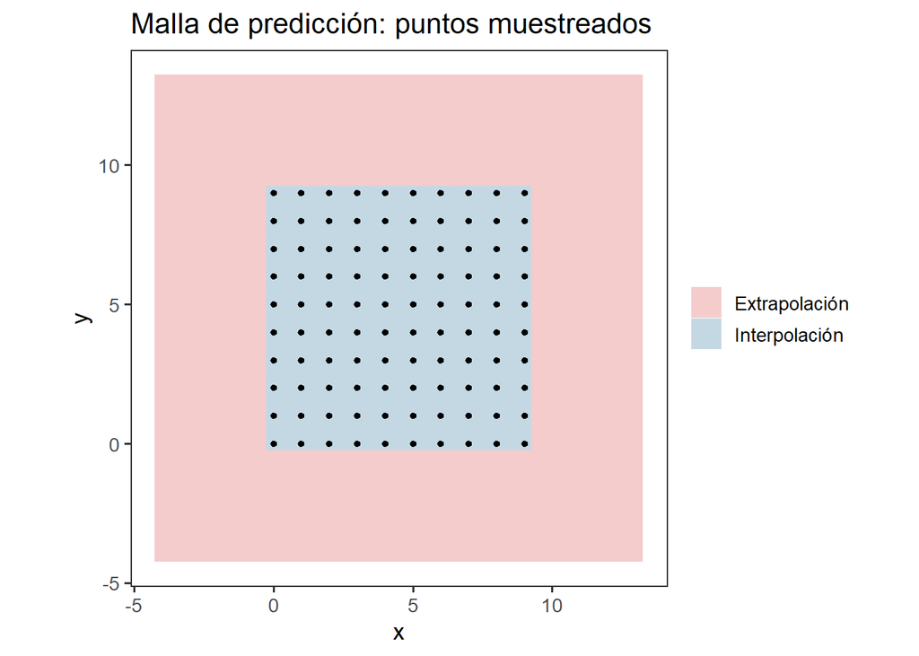

```r
ggplot() +
  geom_tile(data = malla_sim, aes(x, y, fill = zona), alpha = 0.3) +
  geom_point(data = grid, aes(x, y), color = "black", size = 1.2) +
  coord_equal() + theme_test(base_size = 13) +
  scale_fill_manual(values = c("Interpolación" = "#3a7ca5", "Extrapolación" = "#d9534f"), name = NULL) +
  labs(title = "Malla de predicción: puntos muestreados", x = "x", y = "y")
```

## 3.3 Media constante: Kriging ordinario

**Mostrar/ocultar código**

```r
ko_cte <- krige(z ~ 1, sf_cte, malla_sim_sf, model = modelo_cte_fit)
```

```
[using ordinary kriging]
```

**Mostrar/ocultar código**

```r
malla_sim$ko_cte_pred <- ko_cte$var1.pred
malla_sim$ko_cte_sd   <- sqrt(pmax(ko_cte$var1.var, 0))  # pmax evita NaN por varianzas negativas de redondeo en los puntos muestreados
```

**Mostrar/ocultar código**

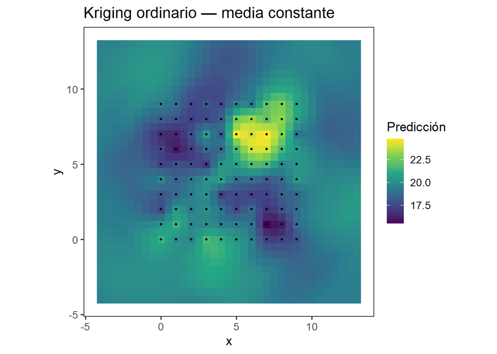

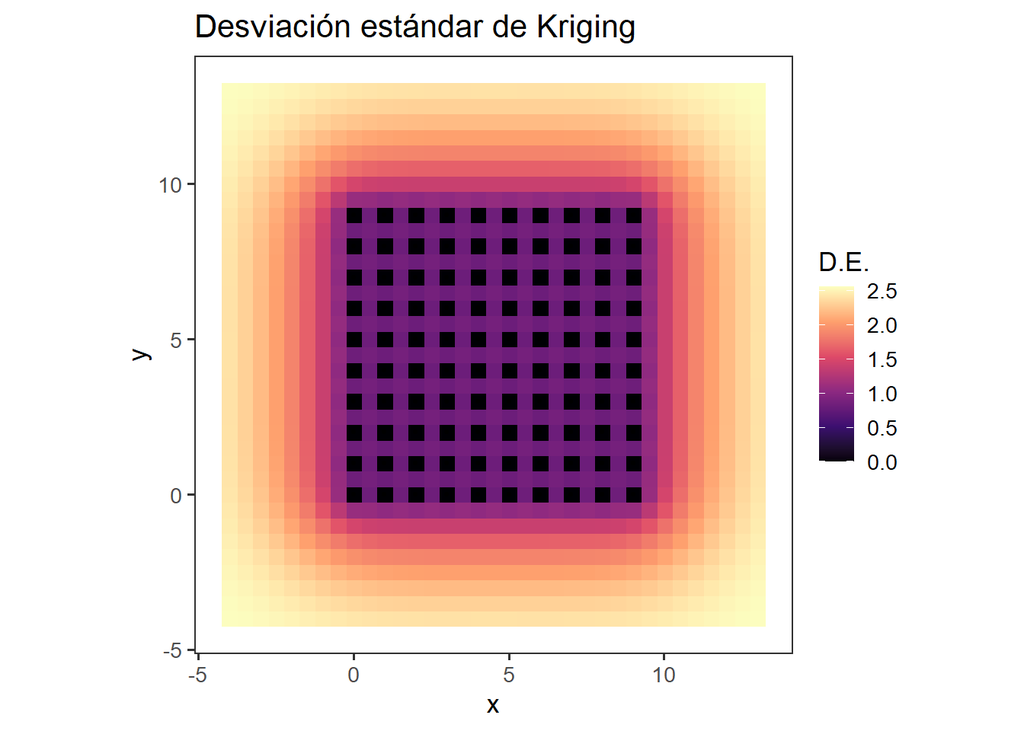

```r
ggplot(malla_sim, aes(x, y, fill = ko_cte_pred)) + geom_raster() +
  geom_point(data = grid, aes(x, y), inherit.aes = FALSE, size = 0.6) +
  scale_fill_viridis_c(name = "Predicción") + coord_equal() + theme_test(base_size = 13) +
  labs(title = "Kriging ordinario — media constante")
ggplot(malla_sim, aes(x, y, fill = ko_cte_sd)) + geom_raster() +
  geom_point(data = grid, aes(x, y), inherit.aes = FALSE, size = 0.6) +
  scale_fill_viridis_c(name = "D.E.", option = "magma") + coord_equal() + theme_test(base_size = 13) +
  labs(title = "Desviación estándar de Kriging")
```

Con una media efectivamente constante, el Kriging ordinario se comporta como se espera: predicciones suaves cerca de los datos, que se aproximan a la media global a medida que nos alejamos de ellos (zona roja de la malla), y una desviación estándar que crece con la distancia a las observaciones más cercanas.

## 3.4 Media con tendencia: ¿qué pasa si usamos Kriging ordinario de todas formas?

Ahora aplicamos Kriging ordinario (`z ~ 1`, sin tendencia explícita) a los datos **con** tendencia, usando su propio modelo de semivariograma (`modelo_ncte_fit`, ajustado sobre los residuales de la tendencia). Esto es deliberadamente “incorrecto”: estamos ignorando la tendencia en la etapa de predicción, precisamente para poder mostrar, con un ejemplo controlado, qué tan costoso es ese error.

**Mostrar/ocultar código**

```r
ko_ncte_mal <- krige(z ~ 1, sf_ncte, malla_sim_sf, model = modelo_ncte_fit)
```

```
[using ordinary kriging]
```

**Mostrar/ocultar código**

```r
malla_sim$ko_ncte_pred <- ko_ncte_mal$var1.pred
malla_sim$verdad       <- 10 + 2*malla_sim$x + 3*malla_sim$y
```

**Mostrar/ocultar código**

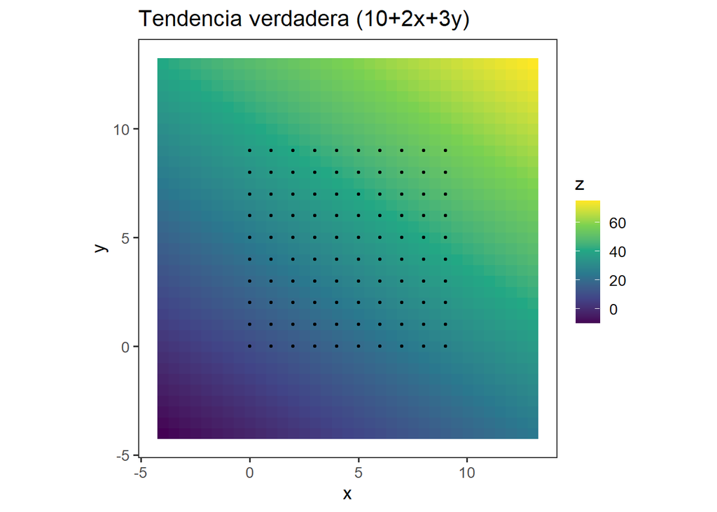

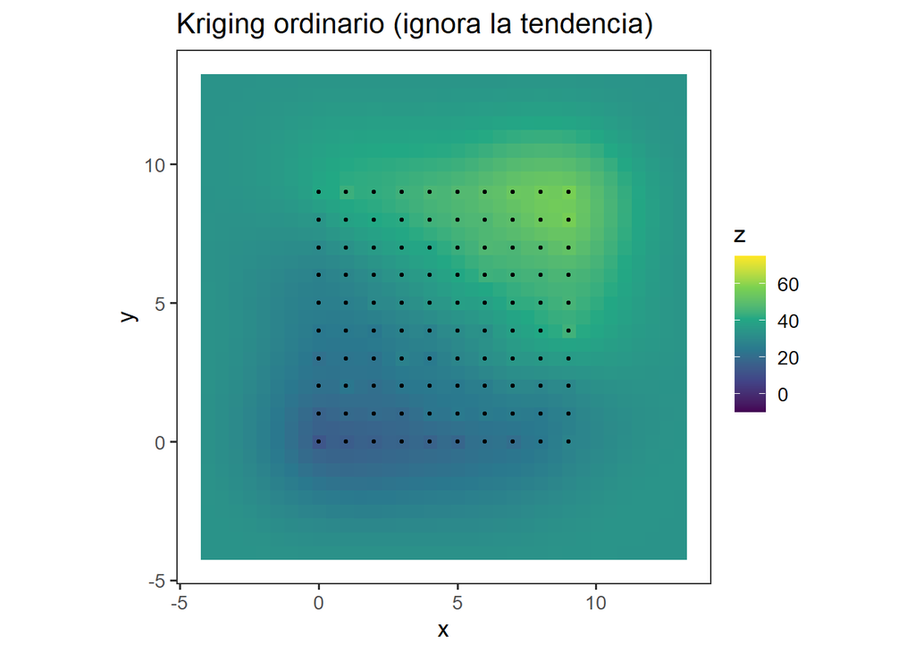

```r
rango_ko_verdad <- range(c(malla_sim$verdad, malla_sim$ko_ncte_pred))

ggplot(malla_sim, aes(x, y, fill = verdad)) + geom_raster() +
  geom_point(data = grid, aes(x, y), inherit.aes = FALSE, size = 0.6) +
  scale_fill_viridis_c(name = "z", limits = rango_ko_verdad) + coord_equal() + theme_test(base_size = 13) +
  labs(title = "Tendencia verdadera (10+2x+3y)")
ggplot(malla_sim, aes(x, y, fill = ko_ncte_pred)) + geom_raster() +
  geom_point(data = grid, aes(x, y), inherit.aes = FALSE, size = 0.6) +
  scale_fill_viridis_c(name = "z", limits = rango_ko_verdad) + coord_equal() + theme_test(base_size = 13) +
  labs(title = "Kriging ordinario (ignora la tendencia)")
```

**Mostrar/ocultar código**

```r
cor_ko_extrap   <- cor(malla_sim$ko_ncte_pred[malla_sim$zona == "Extrapolación"],
                        malla_sim$verdad[malla_sim$zona == "Extrapolación"])
rango_ko_extrap <- range(malla_sim$ko_ncte_pred[malla_sim$zona == "Extrapolación"])
```

Los puntos negros marcan las 100 ubicaciones muestreadas. Dentro de ese cuadrado, la predicción del Kriging ordinario sigue razonablemente la superficie verdadera, porque ahí siempre hay observaciones cercanas que la anclan: al final, el *kriging* —ordinario o universal— es un promedio ponderado de los datos vecinos. El problema aparece en la zona de “Extrapolación” que definimos antes: el Kriging ordinario asume una única media global constante, y lejos de cualquier dato que lo corrija, su predicción se queda pegada cerca de esa media global en lugar de seguir el gradiente diagonal. La magnitud del problema es clara en los números: en esa zona, las predicciones de KO varían apenas entre 17.3 y 52.6, mientras que la tendencia verdadera recorre un rango mucho más amplio, de $-10$ a $75$, en esas mismas ubicaciones; la correlación entre la predicción de KO y esa tendencia verdadera, calculada solo en la zona de extrapolación, es de 0.65 —ya no nula, porque algunos puntos de la zona de extrapolación quedan cerca del borde del cuadrado muestreado, pero claramente insuficiente para una extrapolación confiable—.

**La conclusión es clara:** ignorar una tendencia de gran escala no es un error “menor” cuando el objetivo es predecir fuera de la nube de datos. El Kriging ordinario no tiene, por construcción, ningún mecanismo para continuar un gradiente que no sabe que existe; en el mejor de los casos amortigua su predicción hacia la media muestral, y en el peor, la extrapolación pierde casi todo contacto con la realidad. Veamos a continuación qué cambia si sí le decimos al modelo que existe una tendencia.

## 3.5 Media con tendencia: Kriging universal

**Mostrar/ocultar código**

```r
malla_sim_sf$x <- malla_sim$x
malla_sim_sf$y <- malla_sim$y
ku_ncte <- krige(z ~ x + y, sf_ncte, malla_sim_sf, model = modelo_ncte_fit)
```

```
[using universal kriging]
```

**Mostrar/ocultar código**

```r
malla_sim$ku_ncte_pred <- ku_ncte$var1.pred
```

`krige(z ~ x + y, ...)` realiza **Kriging universal**: `gstat` estima, por mínimos cuadrados generalizados (GLS) —usando `modelo_ncte_fit` para describir la correlación espacial de los residuales—, los coeficientes de una tendencia lineal en `x` y `y`, y predice sumando esa tendencia estimada con la corrección kriged de los residuales espacialmente correlacionados. Podemos recuperar esos coeficientes evaluando la tendencia ajustada en tres ubicaciones específicas (`BLUE = TRUE` le pide a `gstat` la tendencia ajustada, en vez de la predicción kriged completa) y compararlos con los verdaderos (10, 2 y 3):

**Mostrar/ocultar código**

```r
g_fit_ncte <- gstat(formula = z ~ x + y, data = sf::as_Spatial(sf_ncte), model = modelo_ncte_fit)
pts_coef   <- sf::as_Spatial(st_as_sf(data.frame(x = c(0, 1, 0), y = c(0, 0, 1)),
                                       coords = c("x", "y"), remove = FALSE))
coef_blue  <- as.data.frame(predict(g_fit_ncte, newdata = pts_coef, BLUE = TRUE))
```

```
[generalized least squares trend estimation]
```

**Mostrar/ocultar código**

```r
tabla_coef <- tibble(
  parametro = c("Intercepto", "Pendiente en x", "Pendiente en y"),
  estimado  = c(coef_blue$var1.pred[1],
                coef_blue$var1.pred[2] - coef_blue$var1.pred[1],
                coef_blue$var1.pred[3] - coef_blue$var1.pred[1]),
  verdadero = c(10, 2, 3)
)
kable(tabla_coef, digits = 2, caption = "Coeficientes de la tendencia estimados por GLS (Kriging universal) vs. valores verdaderos")
```

Coeficientes de la tendencia estimados por GLS (Kriging universal) vs. valores verdaderos

| parametro | estimado | verdadero |
| --- | --- | --- |
| Intercepto | 10.76 | 10 |
| Pendiente en x | 1.87 | 2 |
| Pendiente en y | 3.25 | 3 |

Los tres coeficientes se recuperan razonablemente bien con apenas 100 observaciones y una sola realización. Esto es justamente lo que le falta al Kriging ordinario: una tendencia explícita que, una vez estimada, sigue extendiéndose más allá de la nube de datos aunque ya no haya observaciones cercanas que la sostengan.

**Mostrar/ocultar código**

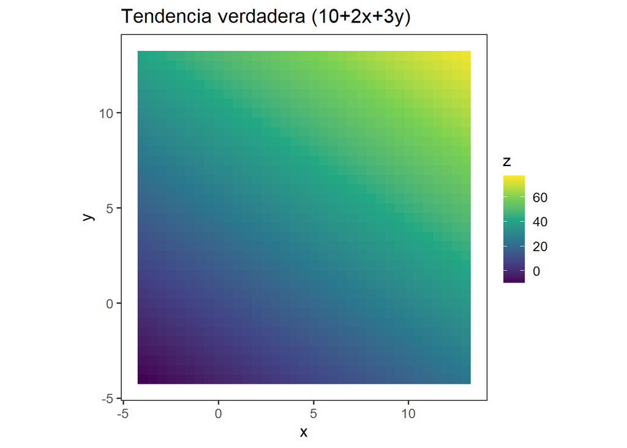

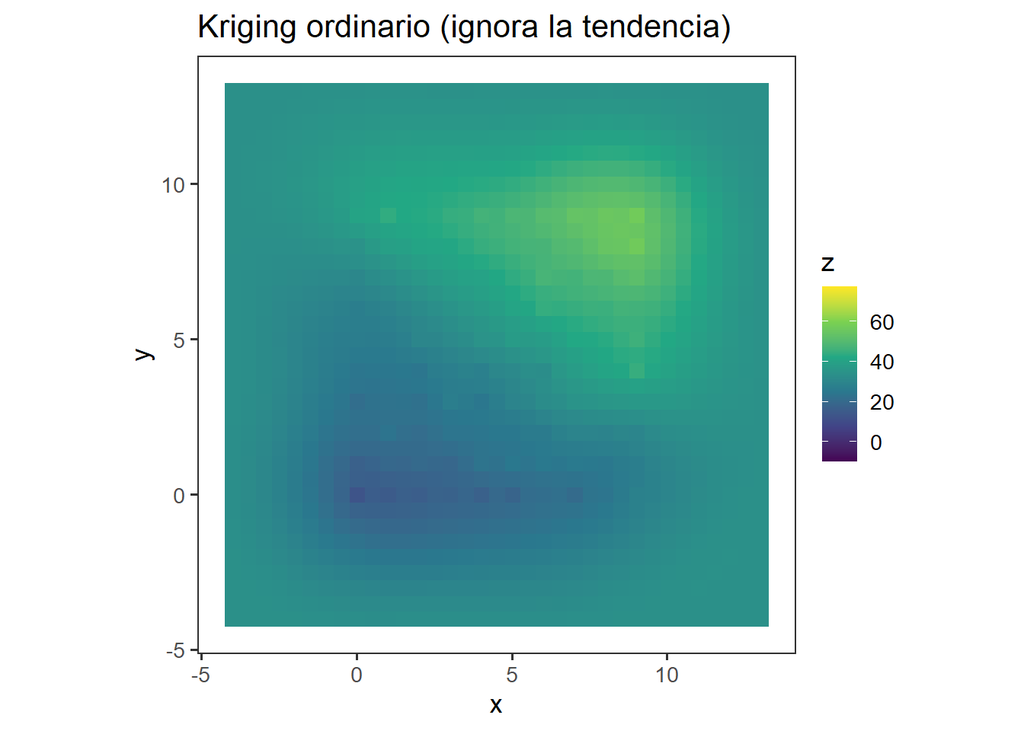

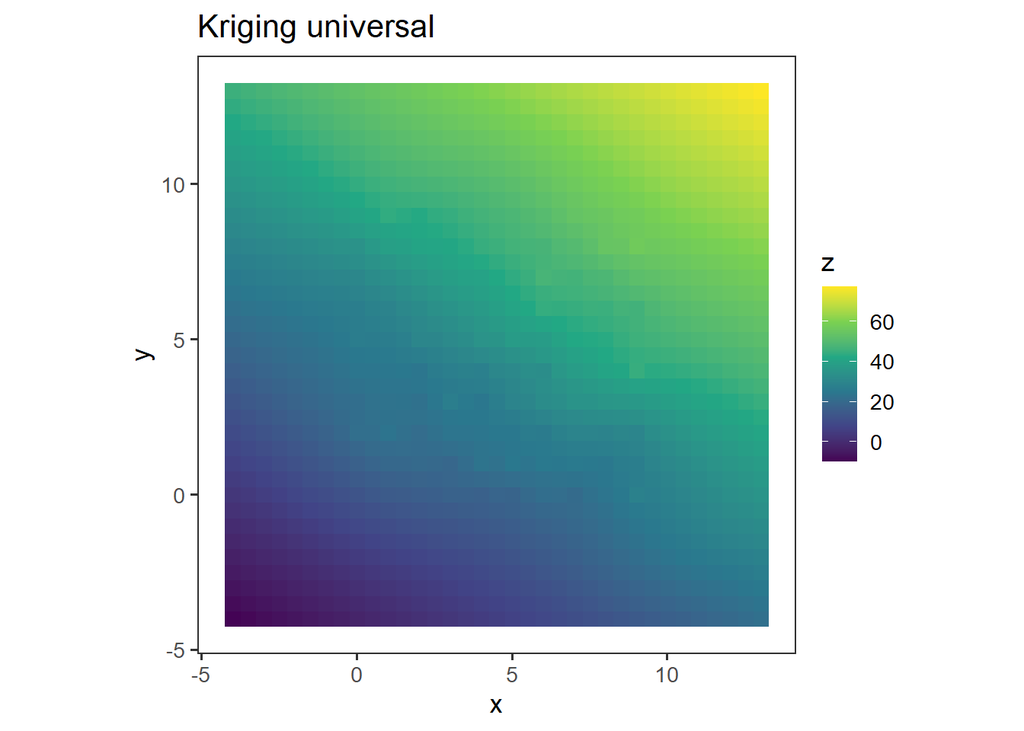

```r
rango_comun <- range(c(malla_sim$ko_ncte_pred, malla_sim$ku_ncte_pred, malla_sim$verdad))

ggplot(malla_sim, aes(x, y, fill = verdad)) + geom_raster() +
  scale_fill_viridis_c(name = "z", limits = rango_comun) + coord_equal() + theme_test(base_size = 13) +
  labs(title = "Tendencia verdadera (10+2x+3y)")
ggplot(malla_sim, aes(x, y, fill = ko_ncte_pred)) + geom_raster() +
  scale_fill_viridis_c(name = "z", limits = rango_comun) + coord_equal() + theme_test(base_size = 13) +
  labs(title = "Kriging ordinario (ignora la tendencia)")
ggplot(malla_sim, aes(x, y, fill = ku_ncte_pred)) + geom_raster() +
  scale_fill_viridis_c(name = "z", limits = rango_comun) + coord_equal() + theme_test(base_size = 13) +
  labs(title = "Kriging universal")
```

**Mostrar/ocultar código**

```r
cor_ku_extrap   <- cor(malla_sim$ku_ncte_pred[malla_sim$zona == "Extrapolación"],
                        malla_sim$verdad[malla_sim$zona == "Extrapolación"])
rango_ku_extrap <- range(malla_sim$ku_ncte_pred[malla_sim$zona == "Extrapolación"])
```

Dentro del cuadrado de muestreo, donde ambos métodos pueden apoyarse en observaciones cercanas, las tres superficies se parecen bastante entre sí —tal como anticipamos, la diferencia entre KO y KU casi no se nota en interpolación—. La diferencia salta a la vista en las esquinas extendidas: el Kriging ordinario se aplana, como vimos en la sección anterior, mientras que el Kriging universal sigue extendiendo el gradiente diagonal de forma muy parecida a la superficie verdadera. Los números de la zona de extrapolación lo confirman: ahí la correlación de KO con la verdad era de apenas 0.65, mientras que la del Kriging universal es de 1.00; y su rango de predicciones (-9.7 a 77.3) prácticamente coincide con el rango real de la tendencia en esa misma zona ($-10$ a $75$), en contraste con el rango mucho más angosto que vimos para KO.

## 3.6 Comparación cuantitativa en la zona de extrapolación

**Mostrar/ocultar código**

```r
extrap <- malla_sim$zona == "Extrapolación"
tabla_extrap <- tibble(
  metodo = c("Kriging ordinario", "Kriging universal"),
  correlacion_con_verdad = c(cor(malla_sim$ko_ncte_pred[extrap], malla_sim$verdad[extrap]),
                              cor(malla_sim$ku_ncte_pred[extrap], malla_sim$verdad[extrap])),
  rango_predicho = c(paste(round(range(malla_sim$ko_ncte_pred[extrap]), 1), collapse = " a "),
                      paste(round(range(malla_sim$ku_ncte_pred[extrap]), 1), collapse = " a "))
)
kable(tabla_extrap, digits = 3, caption = "Comparación SOLO en la zona de extrapolación (rango verdadero: -10 a 75)")
```

Comparación SOLO en la zona de extrapolación (rango verdadero: -10 a 75)

| metodo | correlacion_con_verdad | rango_predicho |
| --- | --- | --- |
| Kriging ordinario | 0.649 | 17.3 a 52.6 |
| Kriging universal | 0.997 | -9.7 a 77.3 |

**Importante**

Esta es la razón conceptual para preferir el Kriging universal cuando se sospecha una tendencia de gran escala: **no** es porque prediga mejor dentro de la zona bien muestreada, sino porque es el único de los dos que puede **extrapolar razonablemente** la tendencia más allá de los datos observados.

# 4 Validación cruzada sobre los datos simulados

**Mostrar/ocultar código**

```r
cv_cte  <- krige.cv(z ~ 1,     sf_cte,  model = modelo_cte_fit,  verbose = FALSE)
cv_ncte <- krige.cv(z ~ x + y, sf_ncte, model = modelo_ncte_fit, verbose = FALSE)

tabla_cv_sim <- tibble(
  caso = c("Media constante (KO)", "Media con tendencia (KU)"),
  RMSE = c(sqrt(mean(cv_cte$residual^2)), sqrt(mean(cv_ncte$residual^2))),
  Cor_obs_pred = c(cor(cv_cte$observed, cv_cte$observed - cv_cte$residual),
                   cor(cv_ncte$observed, cv_ncte$observed - cv_ncte$residual))
)
kable(tabla_cv_sim, digits = 3, caption = "Validación cruzada leave-one-out — datos simulados")
```

Validación cruzada leave-one-out — datos simulados

| caso | RMSE | Cor_obs_pred |
| --- | --- | --- |
| Media constante (KO) | 1.024 | 0.867 |
| Media con tendencia (KU) | 1.383 | 0.992 |

Dentro de la zona muestreada, ambos modelos predicen razonablemente bien sus propios datos (el RMSE es del orden de la desviación estándar del efecto de pequeña escala del modelo simulado). Esto confirma que la diferencia entre KO y KU no es de desempeño predictivo *interno*, sino de capacidad de extrapolación, como ya vimos.

# 5 Predicción de temperatura en la Ciénaga Grande

## 5.1 Repaso: los datos y los modelos de semivariograma ajustados

**Mostrar/ocultar código**

```r
datos.cienaga <- readxl::read_xls("data/base_cienaga.xls")
names(datos.cienaga) <- c("Este", "Norte", "prof", "temp", "sali", "oxig")
datos_sf <- st_as_sf(datos.cienaga, coords = c("Este", "Norte"), crs = 3116, remove = FALSE)

distancia_maxima <- max(dist(st_coordinates(datos_sf))) / 2
ancho_intervalo  <- distancia_maxima / 12

v_sin_tendencia <- variogram(temp ~ 1,            datos_sf, cutoff = distancia_maxima, width = ancho_intervalo)
v_1er_orden     <- variogram(temp ~ Este + Norte, datos_sf, cutoff = distancia_maxima, width = ancho_intervalo)

nugget_inicial <- 0.3
psill_inicial  <- var(datos.cienaga$temp) - nugget_inicial

modelo_sin_tendencia <- suppressWarnings(fit.variogram(
  v_sin_tendencia, vgm(psill = psill_inicial, model = "Sph", range = distancia_maxima/4, nugget = nugget_inicial)))
modelo_con_tendencia <- suppressWarnings(fit.variogram(
  v_1er_orden, vgm(psill = psill_inicial, model = "Sph", range = distancia_maxima/4, nugget = nugget_inicial)))
```

**Importante**

## 5.2 Malla de predicción recortada al polígono de la ciénaga

Reutilizamos el contorno de la Práctica 3 (cerrando el anillo, que no viene cerrado en el archivo original) para generar una malla regular y recortarla a la forma real del cuerpo de agua, en lugar de predecir sobre un rectángulo que incluiría tierra firme.

**Mostrar/ocultar código**

```r
contorno_df <- read.table("data/cienaga_border.txt", header = TRUE)

primero <- as.numeric(contorno_df[1, ])
ultimo  <- as.numeric(contorno_df[nrow(contorno_df), ])
if (!isTRUE(all.equal(primero, ultimo))) contorno_df <- rbind(contorno_df, contorno_df[1, ])

poligono <- st_sf(geometry = st_sfc(st_polygon(list(as.matrix(contorno_df))), crs = 3116))

malla_real <- st_make_grid(poligono, cellsize = 400, what = "centers") %>% st_as_sf()
malla_real <- malla_real[st_within(malla_real, poligono, sparse = FALSE)[, 1], ]
malla_real$Este  <- st_coordinates(malla_real)[, 1]
malla_real$Norte <- st_coordinates(malla_real)[, 2]

cat("Número de puntos de la malla de predicción (recortada al polígono):", nrow(malla_real), "\n")
```

```
Número de puntos de la malla de predicción (recortada al polígono): 2782
```

**Mostrar/ocultar código**

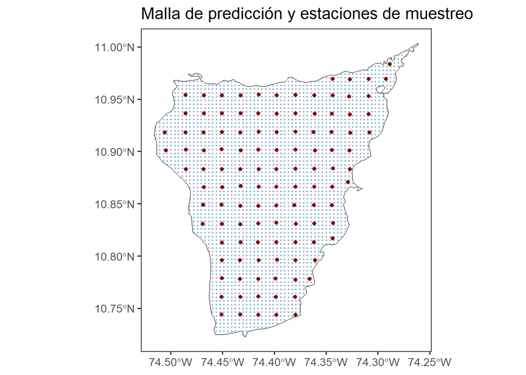

```r
ggplot() +
  geom_sf(data = poligono, fill = NA, color = "black") +
  geom_sf(data = malla_real, size = 0.3, color = "#3a7ca5", alpha = 0.5) +
  geom_sf(data = datos_sf, size = 1.5, color = "darkred") +
  theme_test(base_size = 13) +
  labs(title = "Malla de predicción y estaciones de muestreo")
```

## 5.3 Kriging ordinario y Kriging universal

**Mostrar/ocultar código**

```r
ko_real <- krige(temp ~ 1, datos_sf, malla_real, model = modelo_sin_tendencia)
```

```
[using ordinary kriging]
```

**Mostrar/ocultar código**

```r
ku_real <- krige(temp ~ Este + Norte, datos_sf, malla_real, model = modelo_con_tendencia)
```

```
[using universal kriging]
```

**Mostrar/ocultar código**

```r
malla_real$ko_pred <- ko_real$var1.pred
malla_real$ko_sd   <- sqrt(pmax(ko_real$var1.var, 0))
malla_real$ku_pred <- ku_real$var1.pred
malla_real$ku_sd   <- sqrt(pmax(ku_real$var1.var, 0))
```

**Mostrar/ocultar código**

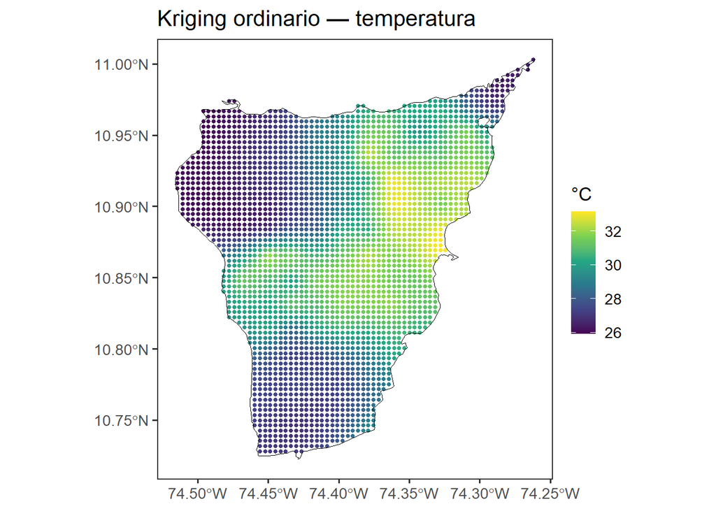

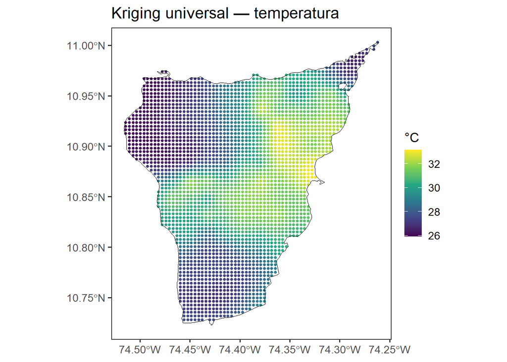

```r
rango_pred_comun <- range(c(malla_real$ko_pred, malla_real$ku_pred))

ggplot(malla_real, aes(color = ko_pred)) + geom_sf(size = 1) +
  geom_sf(data = poligono, fill = NA, color = "black", inherit.aes = FALSE) +
  scale_color_viridis_c(name = "°C", limits = rango_pred_comun) + theme_test(base_size = 13) +
  labs(title = "Kriging ordinario — temperatura")
ggplot(malla_real, aes(color = ku_pred)) + geom_sf(size = 1) +
  geom_sf(data = poligono, fill = NA, color = "black", inherit.aes = FALSE) +
  scale_color_viridis_c(name = "°C", limits = rango_pred_comun) + theme_test(base_size = 13) +
  labs(title = "Kriging universal — temperatura")
```

**Mostrar/ocultar código**

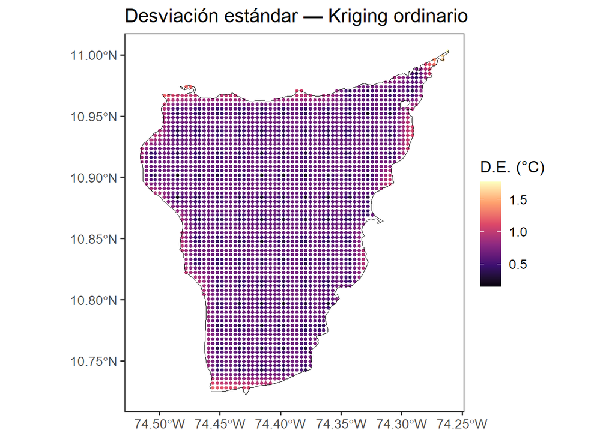

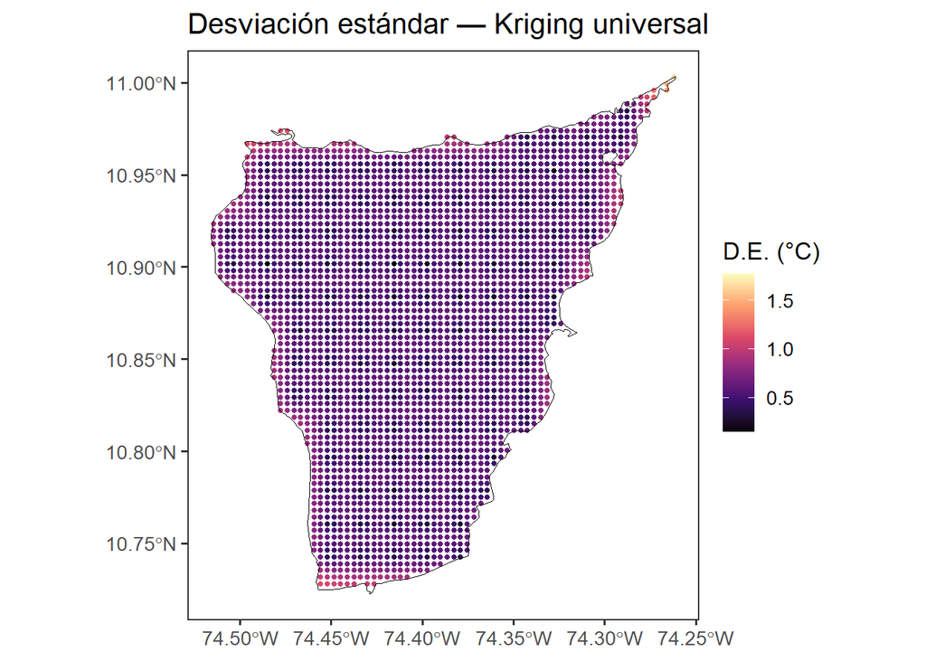

```r
rango_sd_comun <- range(c(malla_real$ko_sd, malla_real$ku_sd))

ggplot(malla_real, aes(color = ko_sd)) + geom_sf(size = 1) +
  geom_sf(data = poligono, fill = NA, color = "black", inherit.aes = FALSE) +
  scale_color_viridis_c(name = "D.E. (°C)", option = "magma", limits = rango_sd_comun) + theme_test(base_size = 13) +
  labs(title = "Desviación estándar — Kriging ordinario")
ggplot(malla_real, aes(color = ku_sd)) + geom_sf(size = 1) +
  geom_sf(data = poligono, fill = NA, color = "black", inherit.aes = FALSE) +
  scale_color_viridis_c(name = "D.E. (°C)", option = "magma", limits = rango_sd_comun) + theme_test(base_size = 13) +
  labs(title = "Desviación estándar — Kriging universal")
```

# 6 Validación cruzada sobre los datos reales

**Mostrar/ocultar código**

```r
cv_sin_tendencia <- krige.cv(temp ~ 1, datos_sf, model = modelo_sin_tendencia, verbose = FALSE)
cv_con_tendencia <- krige.cv(temp ~ Este + Norte, datos_sf, model = modelo_con_tendencia, verbose = FALSE)

tabla_cv_real <- tibble(
  modelo = c("Sin remover tendencia", "Con tendencia de 1er orden"),
  RMSE = c(sqrt(mean(cv_sin_tendencia$residual^2)), sqrt(mean(cv_con_tendencia$residual^2))),
  Cor_obs_pred = c(
    cor(cv_sin_tendencia$observed, cv_sin_tendencia$observed - cv_sin_tendencia$residual),
    cor(cv_con_tendencia$observed, cv_con_tendencia$observed - cv_con_tendencia$residual)
  )
)
kable(tabla_cv_real, digits = 4, caption = "Comparación de validación cruzada leave-one-out — temperatura, Ciénaga Grande")
```

Comparación de validación cruzada leave-one-out — temperatura, Ciénaga Grande

| modelo | RMSE | Cor_obs_pred |
| --- | --- | --- |
| Sin remover tendencia | 0.7130 | 0.9414 |
| Con tendencia de 1er orden | 0.7204 | 0.9401 |

**Mostrar/ocultar código**

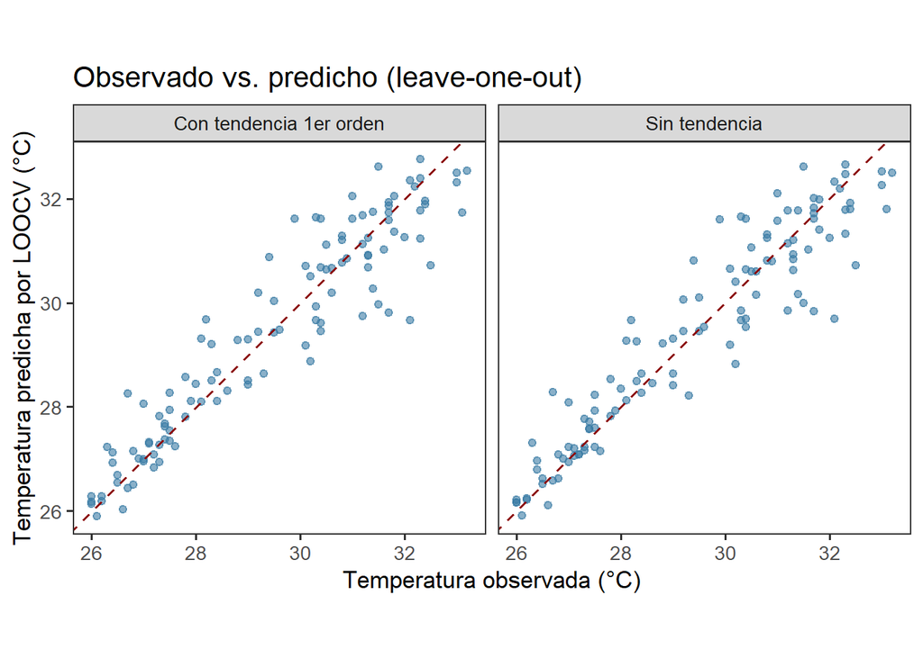

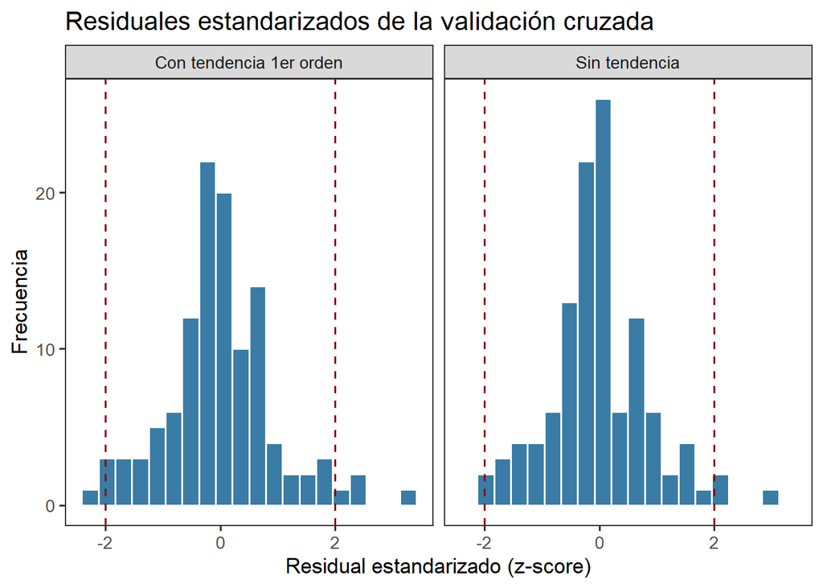

```r
df_cv <- bind_rows(
  tibble(observado = cv_sin_tendencia$observed, predicho = cv_sin_tendencia$observed - cv_sin_tendencia$residual,
         zscore = cv_sin_tendencia$zscore, modelo = "Sin tendencia"),
  tibble(observado = cv_con_tendencia$observed, predicho = cv_con_tendencia$observed - cv_con_tendencia$residual,
         zscore = cv_con_tendencia$zscore, modelo = "Con tendencia 1er orden")
)

ggplot(df_cv, aes(observado, predicho)) +
  geom_point(alpha = 0.6, color = "#3a7ca5") +
  geom_abline(slope = 1, intercept = 0, color = "darkred", linetype = "dashed") +
  facet_wrap(~modelo) + coord_equal() + theme_test(base_size = 13) +
  labs(x = "Temperatura observada (°C)", y = "Temperatura predicha por LOOCV (°C)",
       title = "Observado vs. predicho (leave-one-out)")
ggplot(df_cv, aes(zscore)) +
  geom_histogram(bins = 20, fill = "#3a7ca5", color = "white") +
  geom_vline(xintercept = c(-2, 2), color = "darkred", linetype = "dashed") +
  facet_wrap(~modelo) + theme_test(base_size = 13) +
  labs(x = "Residual estandarizado (z-score)", y = "Frecuencia",
       title = "Residuales estandarizados de la validación cruzada")
```

Los residuales estandarizados (`zscore` en la salida de `krige.cv()`: el residual de predicción dividido por su desviación estándar de Kriging) deberían comportarse, bajo un modelo correctamente especificado, aproximadamente como una normal estándar: la gran mayoría dentro de $\pm 2$. En ambos modelos esto se cumple de forma razonable, lo que respalda usar estos modelos para fines predictivos, incluso con la salvedad ya mencionada sobre la identificabilidad de sus parámetros estructurales.

# 7 Discusión: desempeño predictivo vs. interpretabilidad de los parámetros

Como en la práctica anterior, es interesante notar que el **desempeño predictivo puro** (RMSE, correlación observado/predicho) es muy similar con y sin remoción de tendencia: el Kriging universal ya incorpora implícitamente el gradiente de gran escala como parte de la predicción, incluso cuando el modelo de semivariograma subyacente no tiene un rango claramente identificable. La diferencia importante no está, entonces, en qué tan bien predice cada modelo dentro de la zona muestreada, sino en dos cosas distintas que **sí** importan en otros contextos:

1. **Extrapolación.** Como mostramos con los datos simulados, el Kriging ordinario y el universal se comportan muy diferente fuera de la nube de datos. Si en algún momento se necesitara predecir temperatura fuera del polígono de la ciénaga (lo que no recomendamos sin datos adicionales), esta diferencia sería crítica.
2. **Interpretabilidad de los parámetros estructurales.** Un semivariograma que nunca alcanza una meseta clara no tiene un rango ni una meseta bien estimables, independientemente de qué tan bien prediga. *Ajuste predictivo* y *validez/interpretabilidad de los parámetros estructurales* son dos cosas distintas, y conviene no confundirlas al reportar resultados.

# 8 Buenas prácticas

- Nunca reporte solo el RMSE de un modelo de Kriging: acompáñelo de un diagnóstico de los residuales estandarizados (¿su distribución es razonablemente normal estándar?) y, cuando sea posible, de un mapa de los residuales de validación cruzada.
- Si existe la posibilidad de que se necesite predecir fuera de la zona bien muestreada, evalúe explícitamente el comportamiento de su modelo en extrapolación —como hicimos con la malla extendida— antes de confiar en él para ese propósito.
- Recorte siempre la malla de predicción a la región de interés real (el polígono del cuerpo de agua, la cuenca, el área administrativa); predecir sobre un rectángulo que incluye zonas sin sentido físico desperdicia cómputo y puede inducir a interpretaciones erróneas.
- Reporte tanto el mapa de predicción como el mapa de incertidumbre (varianza o desviación estándar de Kriging): un mapa de predicción sin su incertidumbre asociada es una media verdad.

# 9 Ejercicios propuestos

# 10 Referencias

- Cressie, N. (1993). *Statistics for Spatial Data*. Wiley.
- Pebesma, E. J. (2004). Multivariable geostatistics in S: the gstat package. *Computers & Geosciences*, 30(7), 683-691.
- Diggle, P. J., & Ribeiro Jr, P. J. (2007). *Model-based Geostatistics*. Springer.
- Isaaks, E. H., & Srivastava, R. M. (1989). *An Introduction to Applied Geostatistics*. Oxford University Press.